# Reproducible Research: Peer Assessment 1

## Loading and preprocessing the data

```r
activityData <- read.csv("./activity.csv", header = TRUE,
                         na.strings="NA", sep = ",")
```

## What is mean total number of steps taken per day?

Here we get rid of the NA’s

```r
activityData1 <- activityData[!is.na(activityData[,1]),]
```

1. Calculate the total number of steps taken per day

```r
Tstepday <- aggregate(activityData1$steps,
                      by = list(date = activityData1$date), sum)
colnames(Tstepday) <- c("date", "totalstep")
head(Tstepday)
```

```
##         date totalstep
## 1 2012-10-02       126
## 2 2012-10-03     11352
## 3 2012-10-04     12116
## 4 2012-10-05     13294
## 5 2012-10-06     15420
## 6 2012-10-07     11015
```

2. Histogram of the total number of steps taken per day

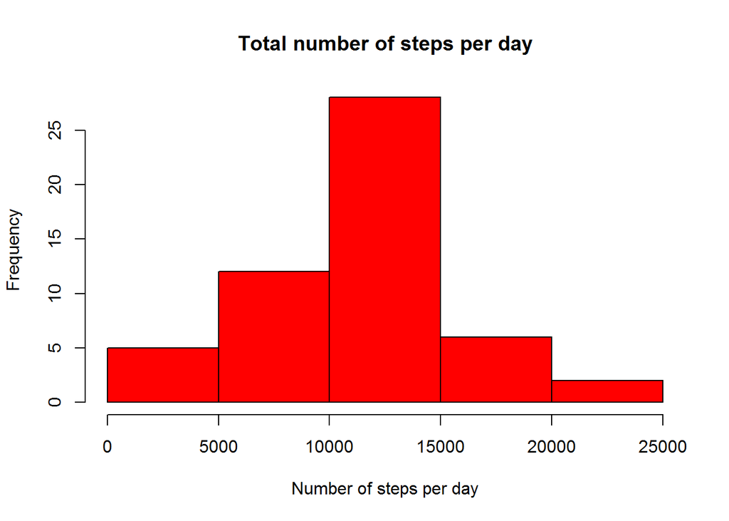

```r
hist(Tstepday$totalstep, xlab = "Number of steps per day", col = "red",
     main= "Total number of steps per day")
```

```r
dev.copy(png, file="./figure/figure1.png",width = 480, height = 480)
dev.off()
```

3. the mean and median of the total number of steps taken per day

```r
meanT <- mean(Tstepday$totalstep)
sprintf("The mean of total number of steps per day is %.3f" , meanT)
```

```
## [1] "The mean of total number of steps per day is 10766.189"
```

```r
medianT <- median(Tstepday$totalstep)
sprintf("The median of total number of steps per day is %s ", medianT)
```

```
## [1] "The median of total number of steps per day is 10765 "
```

## What is the average daily activity pattern?

1. time series plot of average of number of steps per interval across all days

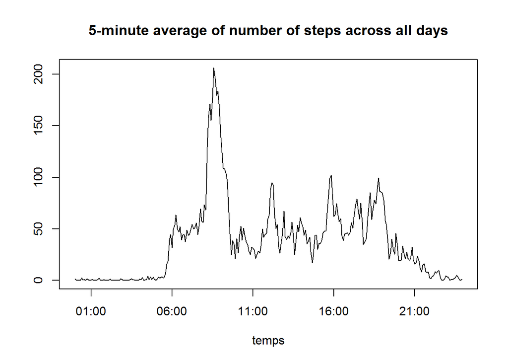

```r
avstepInt <- aggregate(activityData1$steps,
                      by = list(interval = activityData1$interval), mean)
colnames(avstepInt) <- c("interval", "averageStep")
intertime <- strptime(paste(avstepInt$interval %/% 100,avstepInt$interval %% 100
                            ,sep = ":"), "%H:%M")
plot(intertime, avstepInt$averageStep, type = "l", xlab = "temps",
     ylab = "", main = "5-minute average of number of steps across all days")
```

```r
dev.copy(png, file="./figure/figure2.png",width = 480, height = 480)
dev.off()
```

2. Maximum number of steps 5-minute interval

```r
MnStepI <- avstepInt$interval[avstepInt$averageStep == avstepInt$averageStep[which.max(avstepInt$averageStep)]]
sprintf("the interval in which we have the max number of step is %s ", MnStepI)
```

[1] “the interval in which we have the max number of step is 835”

## Imputing missing values

1. the total number of rows with NAs

```r
NumberNA <- nrow(activityData[is.na(activityData[,1]),])
sprintf("the total number of NA is %s ", NumberNA)
```

[1] “the total number of NA is 2304”

Hers we calculate the mean of number of steps per day

```r
meanday <- aggregate(activityData1$steps,
                       by = list(date = activityData1$date), mean)
meanday$x <- floor(meanday$x)
datafilled <- activityData
```

```r
for(i in 1:length(datafilled$date)) {
        for(date in meanday$date) {
                if(is.na(datafilled$steps[i]))
                        datafilled$steps[i] <- meanday$x[meanday$date == date]
        }
}
```

4. Histogram of the total number of steps taken each day

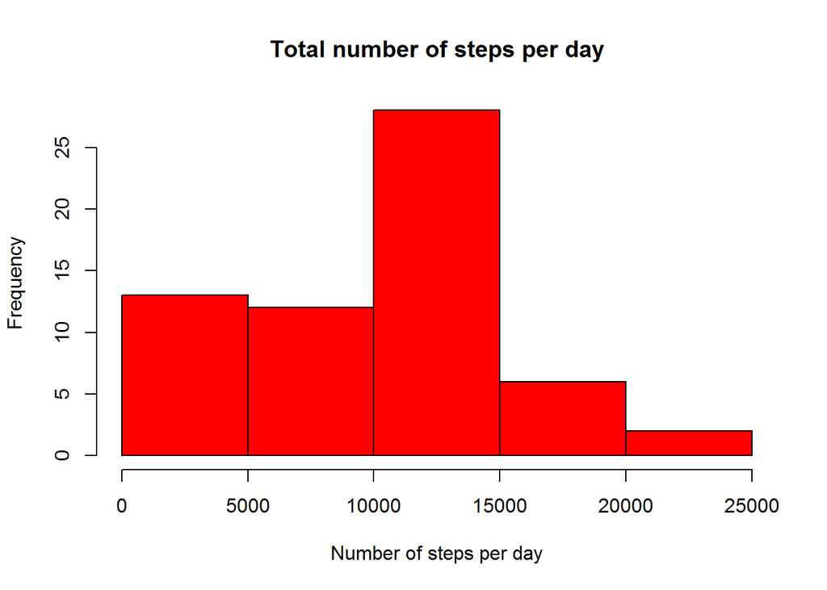

```r
Tstepdayf <- aggregate(datafilled$steps,
                      by = list(date = datafilled$date), sum)
colnames(Tstepdayf) <- c("date", "totalstep")
hist(Tstepdayf$totalstep, xlab = "Number of steps per day", col = "red",
     main= "Total number of steps per day")
```

```r
dev.copy(png, file="./figure/figure3.png",width = 480, height = 480)
dev.off()
```

Here we calculate the mean and median total number of steps taken per day

```r
meandayf <- mean(Tstepdayf$totalstep)
sprintf("The mean of total number of steps per day with filling is %.3f ", meandayf)
```

[1] “The mean of total number of steps per day with filling is 9354.230”

```r
medianf <- median(Tstepdayf$totalstep)
sprintf("The median of total number of steps per day with filling is %s ", medianf)
```

[1] “The median of total number of steps per day with filling is 10395”

## the impact of filling tne NAs is that lower the mean and median

## Are there differences in activity patterns between weekdays and weekends?

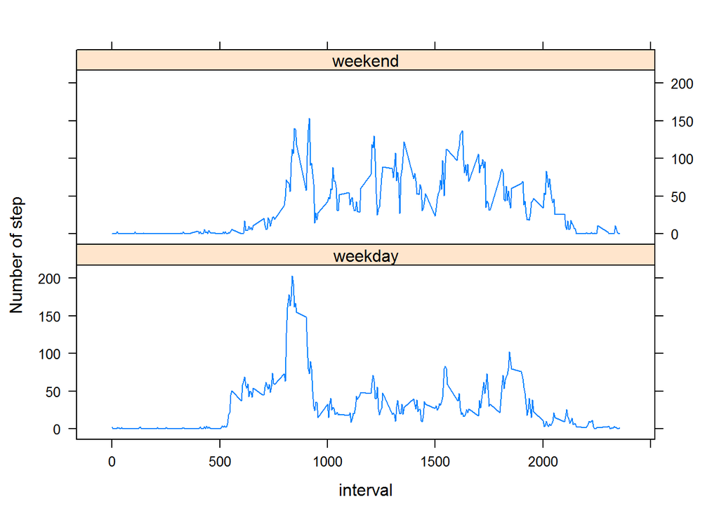

```r
library(lattice)
averageday <- aggregate(datafilled$steps,
               by = list(interval = datafilled$interval, day = datafilled$day)
               , mean)

colnames(averageday) <- c("interval", "day", "averageStep")
xyplot(averageStep ~ interval | day, data=averageday, layout=c(1,2),
       type = "l", ylab = "Number of step")
```

```r
dev.copy(png, file="./figure/figure4.png",width = 480, height = 480)
dev.off()
```

## Conclusion :

we notice some differences between step activity in weekend and weekday:

- in weekend the activity starts slowly and later in the morning compared with the weekday
- in the weekend the activity is more intense and more variable in the day[10H to 19H]